# MA331-Report: 2211606

TED Talks by Speaker Alan Eustace and Speaker Tshering Tobgay

Ghosh Hansda, Sourav

## Introduction

This report is an exploratory analysis of two TED talks, one each by Alan Eustace and Tshering Tobgay. Alan Eustace’s speech took place on October 21, 2014. He is a former Google executive. Tshering Tobgay delivered the speech on April 1, 2016. He is a Bhutanese politician who served as the Prime Minister of Bhutan from 2013 to 2018. The objective of this report is to identify common themes in their speeches and conduct a sentiment analysis of the words uttered.

## Methods

The data used in this analysis is from the ted_talks dataset available in the dsEssex package in R. The dataset contains information about various TED Talks, including the speaker, the title of the talk, and the transcript of the speech.The data preparation process involves loading the required packages, dsEssex, tidyverse, tidytext, ggplot2, and ggrepel. So the dataset is filtered to include speeches by the two speakers and then tokenize the text using the “unnest_tokens()” function from the “tidytext” package. The analysis removes stop words, as well as some words like “laughter” and “applause,” to create a word count table for each speaker. Visualizing the top 25 words used by each speaker is done by using the “slice_max()”, “mutate()”, and “geom_col()” functions from the “ggplot2” package. To compare the top words used by both speakers, the report uses “bind_rows()”, “group_by()”, “filter()”, “pivot_wider()”, and “geom_abline()” functions from “ggplot2” and labels the words using “geom_text_repel()” function from “ggrepel”. Performing sentiment analysis uses the NRC lexicon. It uses the “get_sentiments(”nrc”)” function to obtain the NRC lexicon and joins the lexicon with the tokenized text using “inner_join()”. The analysis counts the number of words associated with each sentiment for each speaker using “count()”, and pivots the data using “pivot_wider()” to create a table with columns for each speaker and rows for each sentiment. It calculates the odds ratio and log odds ratio of each sentiment for each speaker using “mutate()”. The odds ratio is calculated as the ratio of the number of words associated with a sentiment to the number of words not associated with the sentiment. The log odds ratio is calculated as the natural logarithm of the odds ratio.The most common positive and negative sentiment lexicons are extracted from a dataset of talks. First, the unnest_tokens() function is used to separate the text into individual words. The anti_join() function is then used to remove stop words, followed by the inner_join() function to match the remaining words with the National Research Council (NRC) sentiment lexicon, which classifies words as positive, negative, or neutral. The resulting words are then filtered to select only those with positive or negative sentiment, and their frequency is counted using count(). Two plots are created to show the most common positive and negative words. The slice_max() function is used to select the top 10 words, and the fct_reorder() function is used to order the words by frequency. The plots are created using ggplot(), with geom_col() to create a bar plot, and coord_flip() to flip the axes. The x- and y-labels are set using xlab() and ylab(), and the plot titles are set using ggtitle(). Finally, the plots are displayed side by side using grid.arrange().

## Results

The tables of Alan Eustace and Tshering Tobgay show the words they used most frequently in their respective talks.Here Alan has used maximum the word ‘parachute’ 15 times whereas Tshering has used ‘carbon’ 23 times.

```
# A tibble: 476 × 3
   speaker      word             n
   <chr>        <chr>        <int>
 1 Alan Eustace parachute       15
 2 Alan Eustace can             14
 3 Alan Eustace right           12
 4 Alan Eustace one             10
 5 Alan Eustace see             10
 6 Alan Eustace going            9
 7 Alan Eustace stratosphere     9
 8 Alan Eustace suit             9
 9 Alan Eustace balloon          8
10 Alan Eustace system           8
# … with 466 more rows
```

```
# A tibble: 610 × 3
   speaker         word         n
   <chr>           <chr>    <int>
 1 Tshering Tobgay carbon      23
 2 Tshering Tobgay country     22
 3 Tshering Tobgay bhutan      15
 4 Tshering Tobgay neutral     12
 5 Tshering Tobgay together    11
 6 Tshering Tobgay one         10
 7 Tshering Tobgay us          10
 8 Tshering Tobgay world       10
 9 Tshering Tobgay years       10
10 Tshering Tobgay change       9
# … with 600 more rows
```

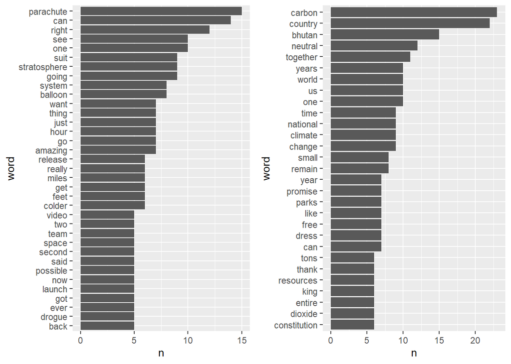

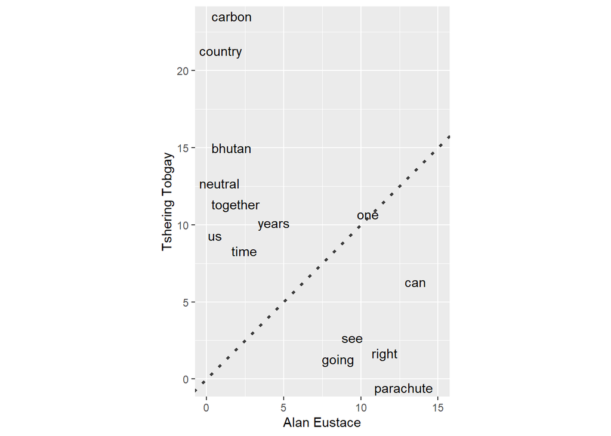

The table below shows which emotions were expressed more frequently by each speaker during the talks.The values in the table show the number of words associated with each emotional tone for each speaker.Here Tshering is showing more trust than Alan & having a more positive & joyous tone.

```
# A tibble: 10 × 3
   sentiment    `Alan Eustace` `Tshering Tobgay`
   <chr>                 <int>             <int>
 1 anger                     3                16
 2 anticipation             36                68
 3 disgust                   3                10
 4 fear                     29                33
 5 joy                      24                65
 6 negative                 27                34
 7 positive                 71               151
 8 sadness                  17                10
 9 surprise                 20                30
10 trust                    42                96
```

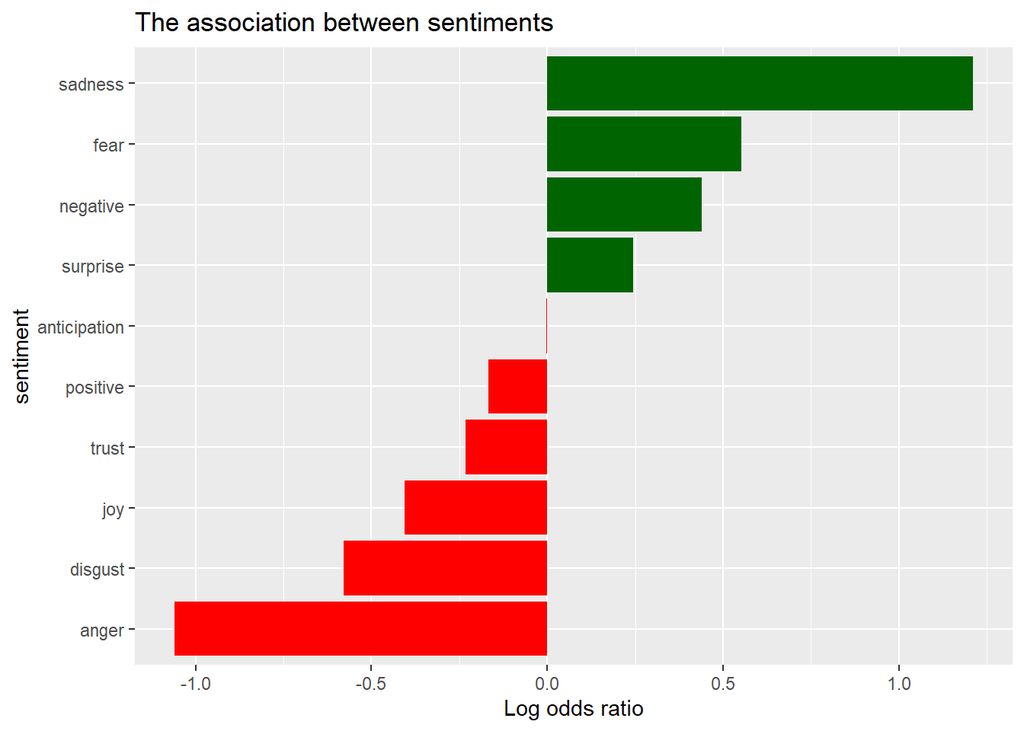

In the following chart, we have displayed the most common positive words and most common negative words used in both the talks.The words like ‘laughter’ & ‘applause’ have more postive impact & on the other hand words like ‘government’, ‘impossible’ & ‘fight’ are having a more negative impact.

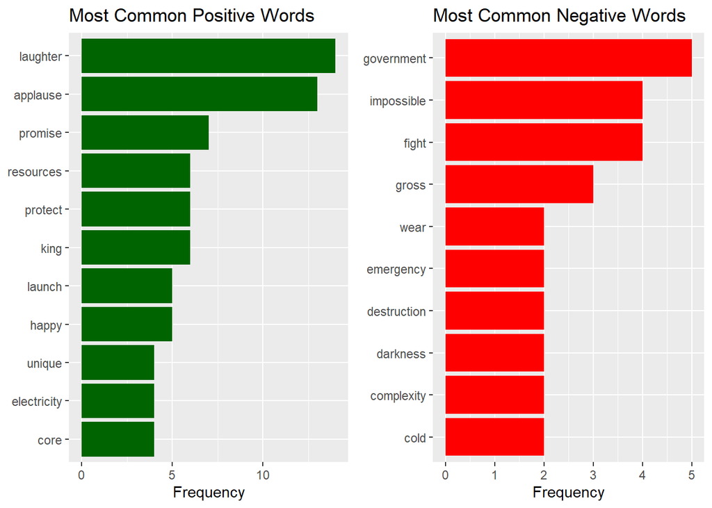